# Data analysis with R Lesson 5

Edited by Raymond Tsang

Mar 2022

- Prerequisite: Fix the issue when knitting html

```r
##Set default repo to fix the issue when publishing html
local({r <- getOption("repos")
       r["CRAN"] <- "http://cran.r-project.org"
       options(repos=r)
})

# # Do not interrupt in case of errors
# knitr::opts_chunk$set(
#   error = TRUE
# )
```

# 5. Lesson 5

- In this lesson, we will focus on sales prediction (Time Series forecasting) analysis.
- Time Series forecasting with Holt-Winters. Holt-Winters forecasting is a way to model and predict the behavior of a sequence of values over time—a time series. Holt-Winters is one of the most popular forecasting techniques for time series. Many other time series forecasting models exist such as ARIMA, TBATS, etc.
- We will demonstrate Time Series forecasting with Holt-Winters model. Other forecasting models such as ARIMA and Seasonal ARIMA models will be used in the evaluation of data modelling.

## 5.1 Sales prediction analysis.

### 5.1.1 Collect data

- Reuse the dataset (filename: R_DA_Data_online_retail_II_clean.csv) which is created in lesson 1 and import it. Reference link of the dataset: https://archive.ics.uci.edu/ml/datasets/Online+Retail+II

```r
df.retail <- read.csv(file = 'R_DA_Data_online_retail_II_clean.csv', header = TRUE, stringsAsFactors = FALSE, strip.white = TRUE, sep = ",")
#data type of InvoiceDate is "chr" from csv format, we convert it back to date-time format by as.POSIXct() function.
df.retail$InvoiceDate <- as.POSIXct(df.retail$InvoiceDate)
```

### 5.1.2 Data preparation for modelling

- In this section, we will focus on below tasks:
  1. Data cleaning
  2. Construct new features of the data used in sales prediction model.
  3. time series setup

#### 5.1.2.1 Data cleaning

1. Data cleaning is the process of identifying, correcting, or removing inaccurate raw data for downstream purposes. It is the process of transforming dirty data into reliable data that can be analyzed. The dataset (df.retail) we are going to use is already cleaned in lesson 1. We reuse the clean dataset.

#### 5.1.2.2 Construct new features of the data used in sales prediction model.

2. Construct new features of the data used in sales prediction model. In our case, we want to have a new feature about Total Sales by day.
   1. Define your target and time horizons: What do you want predict exactly? Sales of the next day given all previous days? Sales of the next month given only the previous 12 months? Sales at each hour of the day?
   2. Build an aggregated dataset: Aggregate sales for each day or month or other timespan depending on what you decided earlier.

```r
# Hourly, daily and monthly split of date time for Invoice date
df.retail$date <- format(df.retail$InvoiceDate, "%m/%d/%Y")
# If you need predict sales at each hour, weekly or monthly, below split of date time is useful.
# df.retail$year <- format(df.retail$InvoiceDate, "%Y")
# df.retail$month <- format(df.retail$InvoiceDate, "%Y-%m")
# df.retail$week <- format(df.retail$InvoiceDate, "%A")
# df.retail$time <- format(df.retail$InvoiceDate, "%H")

#total sales per transaction
df.retail$Total_sales = df.retail$Quantity * df.retail$Price
df.retail
```

| Invoice | StockCode | Description | Quantity | InvoiceDate | Price | CustomerID | Country | date | Total_sales |
| --- | --- | --- | --- | --- | --- | --- | --- | --- | --- |
| 489434 | 85048 | 15CM CHRISTMAS GLASS BALL 20 LIGHTS | 12 | 2009-12-01 07:45:00 | 6.95 | 13085 | United Kingdom | 12/01/2009 | 83.40 |
| 489434 | 79323P | PINK CHERRY LIGHTS | 12 | 2009-12-01 07:45:00 | 6.75 | 13085 | United Kingdom | 12/01/2009 | 81.00 |
| 489434 | 79323W | WHITE CHERRY LIGHTS | 12 | 2009-12-01 07:45:00 | 6.75 | 13085 | United Kingdom | 12/01/2009 | 81.00 |
| 489434 | 22041 | RECORD FRAME 7" SINGLE SIZE | 48 | 2009-12-01 07:45:00 | 2.10 | 13085 | United Kingdom | 12/01/2009 | 100.80 |
| 489434 | 21232 | STRAWBERRY CERAMIC TRINKET BOX | 24 | 2009-12-01 07:45:00 | 1.25 | 13085 | United Kingdom | 12/01/2009 | 30.00 |
| 489434 | 22064 | PINK DOUGHNUT TRINKET POT | 24 | 2009-12-01 07:45:00 | 1.65 | 13085 | United Kingdom | 12/01/2009 | 39.60 |
| 489434 | 21871 | SAVE THE PLANET MUG | 24 | 2009-12-01 07:45:00 | 1.25 | 13085 | United Kingdom | 12/01/2009 | 30.00 |
| 489434 | 21523 | FANCY FONT HOME SWEET HOME DOORMAT | 10 | 2009-12-01 07:45:00 | 5.95 | 13085 | United Kingdom | 12/01/2009 | 59.50 |
| 489435 | 22350 | CAT BOWL | 12 | 2009-12-01 07:46:00 | 2.55 | 13085 | United Kingdom | 12/01/2009 | 30.60 |
| 489435 | 22349 | DOG BOWL , CHASING BALL DESIGN | 12 | 2009-12-01 07:46:00 | 3.75 | 13085 | United Kingdom | 12/01/2009 | 45.00 |

[output cut: 9990 more lines]

```r
#check the range of the InvoiceDate in the data
range(df.retail$InvoiceDate)
```

```
## [1] "2009-12-01 07:45:00 CST" "2011-12-09 12:50:00 CST"
```

```r
#check the new created columns in the data
str(df.retail)
```

```
## 'data.frame':    775087 obs. of  10 variables:
##  $ Invoice    : int  489434 489434 489434 489434 489434 489434 489434 489434 489435 489435 ...
##  $ StockCode  : chr  "85048" "79323P" "79323W" "22041" ...
##  $ Description: chr  "15CM CHRISTMAS GLASS BALL 20 LIGHTS" "PINK CHERRY LIGHTS" "WHITE CHERRY LIGHTS" "RECORD FRAME 7\" SINGLE SIZE" ...
##  $ Quantity   : int  12 12 12 48 24 24 24 10 12 12 ...
##  $ InvoiceDate: POSIXct, format: "2009-12-01 07:45:00" "2009-12-01 07:45:00" ...
##  $ Price      : num  6.95 6.75 6.75 2.1 1.25 1.65 1.25 5.95 2.55 3.75 ...
##  $ CustomerID : int  13085 13085 13085 13085 13085 13085 13085 13085 13085 13085 ...
##  $ Country    : chr  "United Kingdom" "United Kingdom" "United Kingdom" "United Kingdom" ...
##  $ date       : chr  "12/01/2009" "12/01/2009" "12/01/2009" "12/01/2009" ...
##  $ Total_sales: num  83.4 81 81 100.8 30 ...
```

- Select suitable date range and variables for the analysis. We select data during 2009-12-01 and 2011-11-30 (total 730 calendar days). We remove data from 2011-12-01 to 2011-12-09. It can be done by common data manipulation tool in R, dplyr package by below steps:
  1. Filter suitable date range of data
  2. Group by variables
  3. Summarise each group
  4. Sum of all the values in each group or count each group size
  5. Format proper data type and order the rows of a data frame by the values of selected column

```r
# package for data manipulation
install.packages("dplyr")
library("dplyr")
# Total Sales by day
df.retail_sales_day <- df.retail %>%
  filter(InvoiceDate >="2009-12-01" & InvoiceDate <= "2011-11-30")%>%
  group_by(date)%>%
  summarise(Total_sales=sum(Total_sales))%>%
  mutate(date = as.Date(date, "%m/%d/%Y")) %>%
  arrange(date)
df.retail_sales_day
```

| date | Total_sales |
| --- | --- |
| 2009-12-01 | 43222.02 |
| 2009-12-02 | 51386.76 |
| 2009-12-03 | 65173.32 |
| 2009-12-04 | 33256.70 |
| 2009-12-05 | 9627.55 |
| 2009-12-06 | 23990.40 |
| 2009-12-07 | 32259.49 |
| 2009-12-08 | 43889.14 |
| 2009-12-09 | 30231.72 |
| 2009-12-10 | 36733.94 |

[output cut: 585 more lines]

```r
summary(df.retail_sales_day)
```

```
##       date             Total_sales
##  Min.   :2009-12-01   Min.   :  3440
##  1st Qu.:2010-06-07   1st Qu.: 18097
##  Median :2010-11-29   Median : 24851
##  Mean   :2010-12-03   Mean   : 27647
##  3rd Qu.:2011-06-07   3rd Qu.: 33378
##  Max.   :2011-11-29   Max.   :103239
```

```r
#check the data type of date and Total_sales columns
class(df.retail_sales_day$date)
```

```
## [1] "Date"
```

```r
class(df.retail_sales_day$Total_sales)
```

```
## [1] "numeric"
```

```r
#check the date range
range(df.retail_sales_day$date)
```

```
## [1] "2009-12-01" "2011-11-29"
```

```r
#check the number of date
length(df.retail_sales_day$date)
```

```
## [1] 595
```

- It is found that only 595 days in the data! But we select data during 2009-12-01 and 2011-11-30 (total 730 calendar days). The dates are not consecutive during 2009-12-01 and 2011-11-30.
- Plot the Total Sales daily

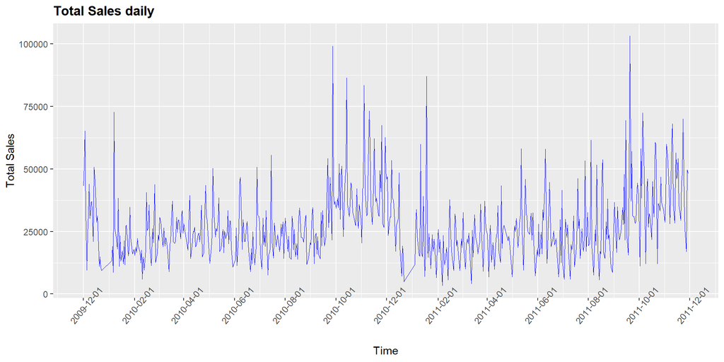

```r
# Install ggplot2 for data visualization.
install.packages("ggplot2")
library("ggplot2")
#plot the data daily
sales_by_day_plot <- ggplot(df.retail_sales_day,aes(x=date, y=Total_sales)) +
  ggtitle("Total Sales daily ") +
  geom_line(colour = "blue", size = 0.1) +
  theme(axis.text.x = element_text(angle = 50),
        plot.title = element_text(face = "bold")) +
  ylab("Total Sales") + xlab("Time") +
  scale_x_date(date_breaks = '2 month')
sales_by_day_plot
```

#### 5.1.2.3 Time series setup

3. Time series setup. Before we do anything regarding forecasting, we need to tell R that this data is a time series.
   - Frequency of a time series is the number of observations per unit of time. When using the time-series ts() function in R, the following choices for frequency should be used.
     1. Annual is 1
     2. Quarterly is 4
     3. Monthly is 12
     4. Weekly is 52
     5. If the frequency of observations is greater than once per week, then there is usually more than one way of handling the frequency. For example, data with daily observations might have a weekly seasonality (frequency=7) or an annual seasonality (frequency=365.25).
   - In this case, we set the parameter “frequency” in the time series by below steps:
     1. The data will be separated into two portions, training set and test set. We will fit the time series data with Holt-Winters method by training set without test set. The test data is used to evaluate its accuracy.
     2. Total number of records of the time series is 595
     3. Training set is 70% of the total records
     4. Total number of records of the training set is 416
     5. Total number of records of the test set is 179
     6. Therefore, the frequency is calculated by the records of the training set over 2, that is 416/2 = 208, because the training set will be fitted with Holt-Winters method and the time series (training set) should have at least 2 periods of the frequency. In short, the frequency cannot be set more than 208.

```r
#Converting to a time series by ts() function
#syntax of ts(data, start, end, frequency)
#data: a vector of the observed time-series values.
#start: the time of the first observation. Either a single number or a vector of two numbers
#end: the time of the last observation. Either a single number or a vector of two numbers
#frequency: the number of observations per unit of time (1=annual, 4=quartly, 12=monthly, etc.).
sales_ts_full <- ts(data = df.retail_sales_day$Total_sales, start = 1, frequency = 208)
#check the data type
class(sales_ts_full)
```

```
## [1] "ts"
```

```r
str(sales_ts_full)
```

```
##  Time-Series [1:595] from 1 to 3.86: 43222 51387 65173 33257 9628 ...
```

### 5.1.3 Data modelling with testing and training data

#### 5.1.3.1 Partitioning dataset into training and test data.

- Partitioning dataset into training and test data. To split a time series we need a vector that is a time series. After the splitting, the training and test data should also be a time series. To partition dataset into training and test data, we can follow below steps:
  1. The size of the test set is typically around 20%-40% of the total sample.
  2. We set the test set is 30% of the total sample in this example. That is, training set is 70% of the total sample.
  3. The forecast package supports head and tail functions for time series. This enables a very handy mechanism for creating train and test sets. All you have to do is provide the size of the training set.
  - Inspect the full data set. Total number of records of the full data set is 595.

```r
#overview of the time series full dataset "sales_ts_full" which we created before.
str(sales_ts_full)
```

```
##  Time-Series [1:595] from 1 to 3.86: 43222 51387 65173 33257 9628 ...
```

```r
#total number of records of the time series
round(length(sales_ts_full))
```

```
## [1] 595
```

- Partitioning dataset into training and test data. Use first 70% data (training data) for forecasting, and remaining data (test data) to test accuracy.

```r
library(forecast)
# Training set
# Use first 70% data for forecasting
sales_ts_train <- head(sales_ts_full, round(length(sales_ts_full) * 0.7))

# Test set
# Use remaining data to test accuracy
h <- length(sales_ts_full) - length(sales_ts_train)
sales_ts_test <- tail(sales_ts_full, h)
```

- We have split dataset into training and test data. Now let’s inspect the training set and test set.
  - Inspect the training set. Total number of records of the training set is 416.

```r
#check the data type of training set
class(sales_ts_train)
```

```
## [1] "ts"
```

```r
#overview of the training set
str(sales_ts_train)
```

```
##  Time-Series [1:416] from 1 to 3: 43222 51387 65173 33257 9628 ...
```

```r
#total number of records of the training set
round(length(sales_ts_train))
```

```
## [1] 416
```

```
* Inspect the test set. Total number of records of the test set is 179.
```

```r
#check the data type of the test set
class(sales_ts_test)
```

```
## [1] "ts"
```

```r
#overview of the test set
str(sales_ts_test)
```

```
##  Time-Series [1:179] from 3 to 3.86: 20553 27178 24979 30286 18623 ...
```

```r
#total number of records of the test set
round(length(sales_ts_test))
```

```
## [1] 179
```

```
* Inspect train and test with the original full data by visualization. Plot train and test data with the original full data. The original full data is plotted by the red dot line, the train data is blue solid line, and the test data is the green solid line.
```

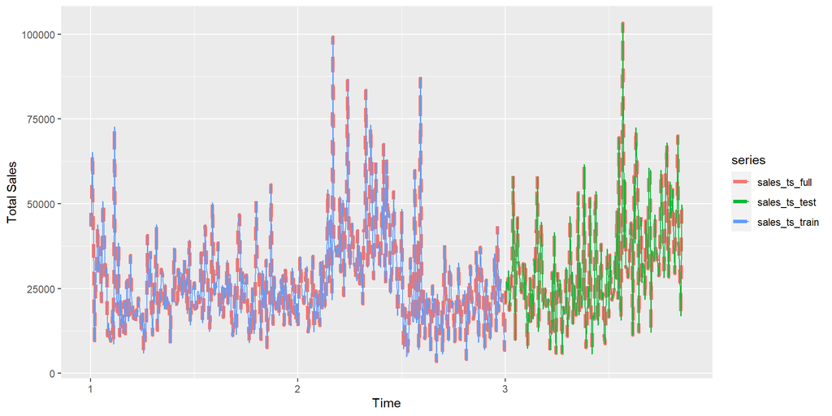

```r
ggplot() + autolayer(sales_ts_full, linetype=2, size=1.5) + autolayer(sales_ts_train) + autolayer(sales_ts_test)+
  xlab("Time") +
  ylab("Total Sales")
```

- At this moment, we have below 3 datasets and all of them are time series.
  1. original full data: sales_ts_full
  2. training data (70% of the original full data): sales_ts_train
  3. test data (30% of the original full data): sales_ts_test

#### 5.1.3.2 Fitting with Holt-Winters.

- Holt-Winters forecasting is a way to model and predict the behavior of a sequence of values over time—a time series. Holt-Winters is one of the most popular forecasting techniques for time series.
- Fitting with Holt-Winters. Before we predict values in the future, we’ll need to create a fit by the data. In the most basic method, we can simply call the Holt-Winters function and let R figure out the tuning parameters on it’s own. We also can tune the fit manually by setting tuning variables to see how the fit changes.
- Syntax of HoltWinters(data, alpha, beta, gamma)
  1. data: An object of class ts (time series)
  2. alpha: the “base value”. Higher alpha puts more weight on the most recent observations.
  3. beta: the “trend value”. Higher beta means the trend slope is more dependent on recent trend slopes.
  4. gamma: the “seasonal component”. Higher gamma puts more weighting on the most recent seasonal cycles.

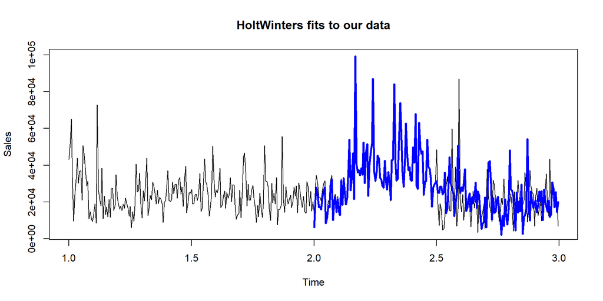

```r
#Holt-Winters function and let R figure out the tuning parameters on it’s own
HW <- HoltWinters(sales_ts_train)

#Visually evaluate the fits to see of how well the HoltWinters model generalizes data similar to that with which it was trained.
plot(sales_ts_train, xlab="Time", ylab="Sales", main = "HoltWinters fits to our data")

#Blue line for Holt-Winters function with the tuning parameters on it’s own
lines(HW$fitted[,1], lty=1, lwd=3, col="blue")
```

#### 5.1.3.3 Forecast Model and Visualize the model

```r
install.packages("forecast")
library("forecast")
```

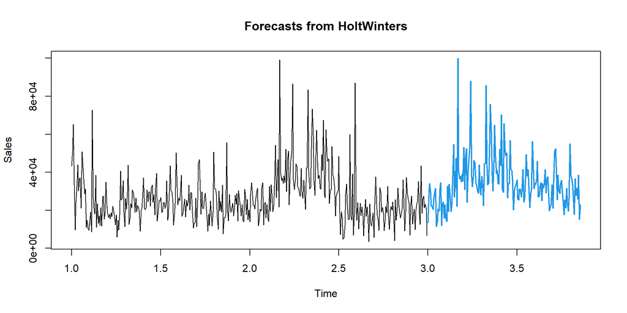

```r
# Using our HW Holt-Winters fit from before, we can use forecast to make new predictions and include both 80% and 95% confidence intervals.
#Syntax of forecast(object, h, level)
#object: a time series
#h: Number of periods for forecasting. In our case, daily data is used and we forecast sales on the next 179 days from the training data. Thus, h is 179.
#level: Confidence level for prediction intervals. Reference: https://towardsdatascience.com/how-confidence-and-prediction-intervals-work-4592019576d8
#0% confidence level means you have no faith at all that if you repeated the survey that you would get the same results. A 100% confidence level means there is no doubt at all that if you repeated the survey you would get the same results.
HW_forecast <- forecast(HW, h=179, level=0)
#visualize our prediction:
plot(HW_forecast, xlab="Time", ylab="Sales")
```

```r
#show the range of the forecast sales
range(HW_forecast$x)
```

```
## [1]  3439.67 99203.62
```

```r
#show the range of total sales of test data
range(sales_ts_test)
```

```
## [1]   5701.87 103238.68
```

- Visualize our prediction with the test data. The prediction values are displayed by blue color, the test data (sales_ts_test) is red line.

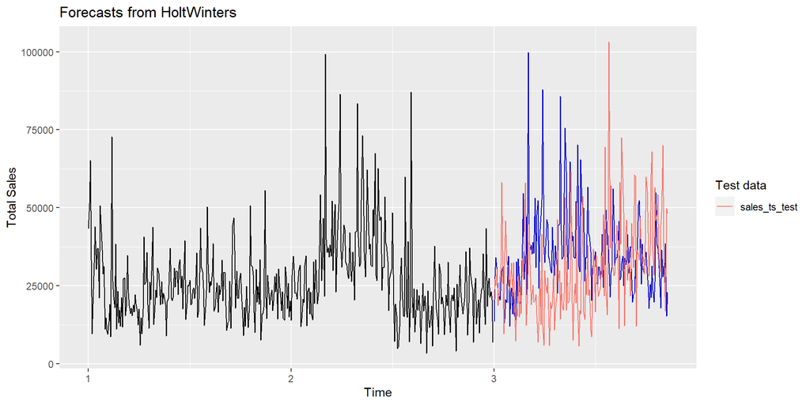

```r
autoplot(HW_forecast) + autolayer(sales_ts_test)+
  xlab("Time") +
  ylab("Total Sales") +
  guides(colour = guide_legend(title = "Test data"))
```

### 5.1.4 Evaluation of data modelling

- In this section, we will use Holt-Winters, ARIMA and Seasonal ARIMA forecasting models together for the evaluation of data modelling. We will apply accuracy measures on these three forecast models to evaluate the performance of them. Then, the best performance forecast model will be used for sales forecasting.
- Steps for evaluation of data modelling:
  1. Build the ARIMA Model and Seasonal ARIMA Model using the same times series as Holt-Winters model.
  2. Perform forecasting by ARIMA Model and Seasonal ARIMA Model
  3. Accuracy measures for Holt-Winters, ARIMA and Seasonal ARIMA forecast models. One of most commonly used scale-dependent measures is based on the Root mean squared error (RMSE). When comparing forecast methods applied to a single time series, or to several time series with the same units, the RMSE is popular as it is easy to both understand and compute.
  4. The forecast model with smaller RMSE value is better. Choose that forecast model for sales forecasting.

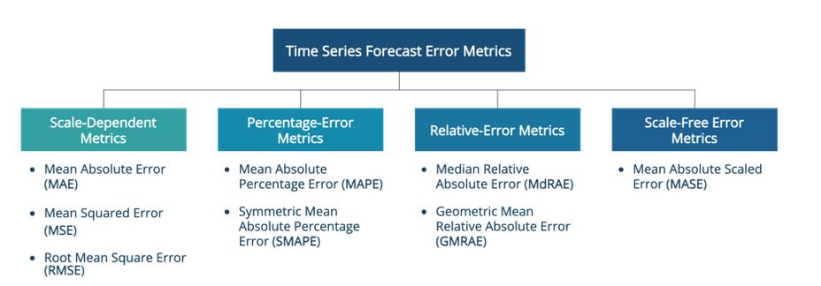

     Figure: Overview of Time Series Forecast Error Metrics. Source: https://towardsdatascience.com/time-series-forecast-error-metrics-you-should-know-cc88b8c67f27

#### 5.1.4.1 Build the ARIMA Model and Seasonal ARIMA Model

- Step 1. Build the ARIMA Model and Seasonal ARIMA Model using the same times series (training set: sales_ts_train) as Holt-Winters model.

```r
# Build the ARIMA Model Using auto.arima() Function
#Syntax of auto.arima(x)
#x: a univariate time series
arima <- auto.arima(sales_ts_train)

# Build the Seasonal ARIMA Model Using auto.sarima() Function
install.packages("bayesforecast")
library(bayesforecast)
#Syntax of auto.sarima(x,seasonal)
#x: a univariate time series
#seasonal: a logical value for seasonal ARIMA models
sarima <- auto.sarima(sales_ts_train, seasonal=T)
```

#### 5.1.4.2 Perform forecasting by ARIMA Model and Seasonal ARIMA Model

- Step 2. Perform forecasting by ARIMA Model and Seasonal ARIMA Model. We forecast sales on the next following 179 days (same as test data) from the training data, which is exactly we have done by Holt-Winters model in above section.

```r
#perform forecasting
arima_forecast <- forecast(arima, level=0, h=179)
sarima_forecast <- forecast(sarima, level=0, h=179)
```

#### 5.1.4.3 Accuracy measures

- Step 3. Accuracy measures for forecast models.
- The measures calculated by accuracy(x) function are:
  1. ME: Mean Error
  2. RMSE: Root Mean Squared Error
  3. MAE: Mean Absolute Error
  4. MPE: Mean Percentage Error
  5. MAPE: Mean Absolute Percentage Error
  6. MASE: Mean Absolute Scaled Error
  7. ACF1: Autocorrelation of errors at lag 1.

```r
library("forecast")
# Accuracy measures for a forecast model by accuracy() function
#syntax of accuracy(x)
#x: An object of class “forecast” containing forecasts.
accuracy(arima_forecast)
```

```
##                     ME     RMSE      MAE       MPE     MAPE      MASE
## Training set -396.5471 11661.67 8156.845 -22.51886 41.33769 0.5601757
##                     ACF1
## Training set -0.00298769
```

```r
accuracy(sarima_forecast)
```

```
##                     ME     RMSE      MAE      MPE     MAPE      MASE       ACF1
## Training set -375.9069 11813.86 8273.384 -22.8823 41.88888 0.5681792 0.07669063
```

```r
accuracy(HW_forecast)
```

```
##                    ME     RMSE      MAE       MPE     MAPE      MASE       ACF1
## Training set 53.80286 10946.59 6448.577 -19.44353 42.89914 0.4428595 0.01334179
```

#### 5.1.4.4 Choose better forecast model for sales forecasting.

- Step 4. The forecast model with smaller RMSE value is better. Holt-Winters forecast model is better. We choose Holt-Winters model for sales forecasting with our data.

```r
accuracy_arima <- accuracy(arima_forecast)
accuracy_sarima <- accuracy(sarima_forecast)
accuracy_HW <- accuracy(HW_forecast)
#compare the RMSE values between the 3 forecast models. Holt-Winters forecast model is better.
accuracy_arima["Training set","RMSE"]
```

```
## [1] 11661.67
```

```r
accuracy_sarima["Training set","RMSE"]
```

```
## [1] 11813.86
```

```r
accuracy_HW["Training set","RMSE"]
```

```
## [1] 10946.59
```

### 5.1.5 Sales forecasting

- Sales forecasting for the next following 100 days afterwards the last day (2011-11-30) in the dataset of the online retail.

```r
#fit the Holt-Winters forecast model with full dataset
HW_full <- HoltWinters(sales_ts_full)
#forecast next 10 days (h=10)
HW_full_forecast <- forecast(HW_full, h=100, level=0)
#show the forecast (forecast sales under "Point Forecast")
HW_full_forecast
```

```
##          Point Forecast Lo 0 Hi 0
## 3.860577       43810.21  NaN  NaN
## 3.865385       40281.97  NaN  NaN
## 3.870192       55662.76  NaN  NaN
## 3.875000       40707.49  NaN  NaN
## 3.879808       43579.62  NaN  NaN
## 3.884615       47605.49  NaN  NaN
## 3.889423       42586.20  NaN  NaN
## 3.894231       39567.60  NaN  NaN
## 3.899038       34104.87  NaN  NaN
## 3.903846       42221.87  NaN  NaN
## 3.908654       40055.94  NaN  NaN
## 3.913462       35466.17  NaN  NaN
## 3.918269       42004.57  NaN  NaN
## 3.923077       41091.36  NaN  NaN
## 3.927885       40262.55  NaN  NaN
## 3.932692       35895.90  NaN  NaN
## 3.937500       46808.74  NaN  NaN
## 3.942308       44412.58  NaN  NaN
## 3.947115       45935.73  NaN  NaN
## 3.951923       35710.03  NaN  NaN
## 3.956731       37213.19  NaN  NaN
## 3.961538       44706.62  NaN  NaN
## 3.966346       33033.32  NaN  NaN
## 3.971154       46089.39  NaN  NaN
## 3.975962       45293.62  NaN  NaN
## 3.980769       36687.55  NaN  NaN
## 3.985577       42137.79  NaN  NaN
## 3.990385       34697.97  NaN  NaN
## 3.995192       32170.50  NaN  NaN
## 4.000000       36231.60  NaN  NaN
## 4.004808       47262.66  NaN  NaN
## 4.009615       50045.51  NaN  NaN
## 4.014423       49792.57  NaN  NaN
## 4.019231       40652.61  NaN  NaN
## 4.024038       41761.44  NaN  NaN
## 4.028846       43310.29  NaN  NaN
## 4.033654       47657.61  NaN  NaN
## 4.038462       60046.60  NaN  NaN
## 4.043269       47044.66  NaN  NaN
```

[output cut: 46 more lines]

```
## 4.269231       54331.01  NaN  NaN
## 4.274038       48989.79  NaN  NaN
## 4.278846       52944.62  NaN  NaN
## 4.283654       50973.79  NaN  NaN
## 4.288462       60131.11  NaN  NaN
## 4.293269       57863.28  NaN  NaN
## 4.298077       46906.46  NaN  NaN
## 4.302885       54917.44  NaN  NaN
## 4.307692       53285.14  NaN  NaN
## 4.312500       57359.85  NaN  NaN
## 4.317308       60968.87  NaN  NaN
## 4.322115       62738.94  NaN  NaN
## 4.326923       81339.50  NaN  NaN
## 4.331731       62399.45  NaN  NaN
## 4.336538       53967.73  NaN  NaN
```

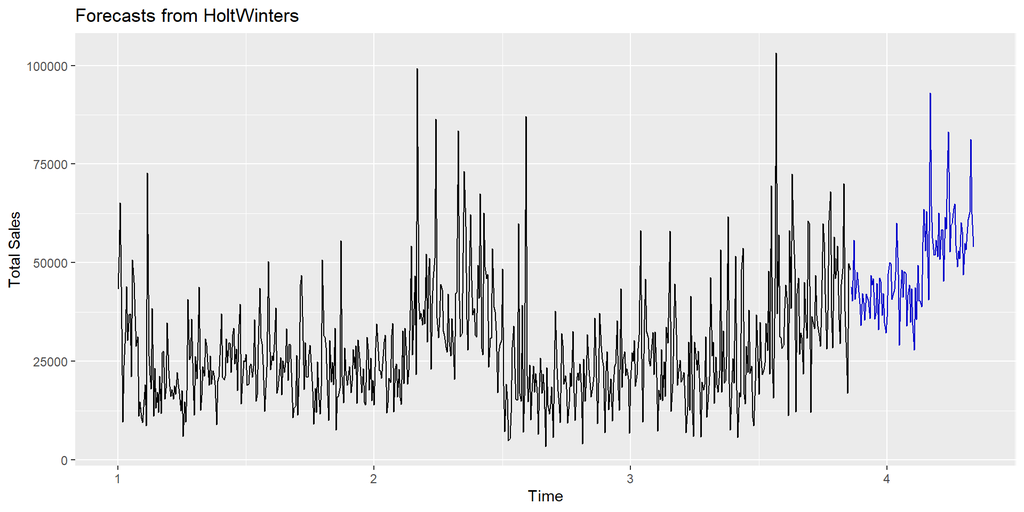

```r
autoplot(HW_full_forecast)+
  xlab("Time") +
  ylab("Total Sales")
```

### 5.1.6 Coursework: Time Series forecasting

- Question: Sales prediction on next 10 days of the online retail (given dataset), based on the data during 2010-06-01 and 2010-12-31. You should follow below procedure:
  1. Data collection
  2. Data preparation for timeseries data, based on the data during 2010-06-01 and 2010-12-31.
  3. Separate the data into train set and test set
  4. Model Fitting with HoltWinters method
  5. Forecast Model
  6. Visualize the model
  7. Sales forecasting on next 10 days of the online retail
- Given dataset. This dataset is already processed data cleaning.

```r
df.retail <- read.csv(file = 'R_DA_Data_online_retail_II_clean.csv', header = TRUE, stringsAsFactors = FALSE, strip.white = TRUE, sep = ",")
#data type of InvoiceDate is "chr" from csv format, we convert it back to date-time format by as.POSIXct() function.
df.retail$InvoiceDate <- as.POSIXct(df.retail$InvoiceDate)
```

## 5.2 References

- Time Series and Forecasting
  - https://www.statmethods.net/advstats/timeseries.html
- Holt-Winters Forecasting
  - https://orangematter.solarwinds.com/2019/12/15/holt-winters-forecasting-simplified/
- Time Series Analysis Using ARIMA Model In R
  - https://datascienceplus.com/time-series-analysis-using-arima-model-in-r/
- UC Irvine Machine Learning Repository
  - https://archive-beta.ics.uci.edu/